# TidyTuesday - Video games dataset

Pablo Cánovas Tourné

July 31, 2019

I recently discovered TidyTuesday, an online data project conducted by [R for Data Science Online Learning Community](https://github.com/rfordatascience) where a dataset is proposed weekly to people to analyze and find some insights using the tools in the [tidyverse](https://www.tidyverse.org/) R ecosystem to clean, wrangle, tidy and plot a new dataset every Tuesday.

This week the dataset was about video games, and I thought it would be nice to take a look at the data.

Let’s start with an overview of the score of the games released by publishers with more titles.

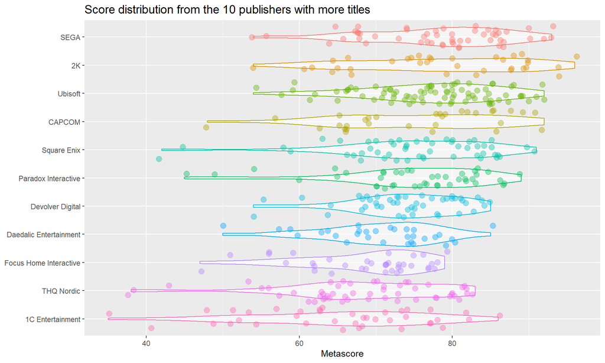

What about the scores of the best rated publishers?

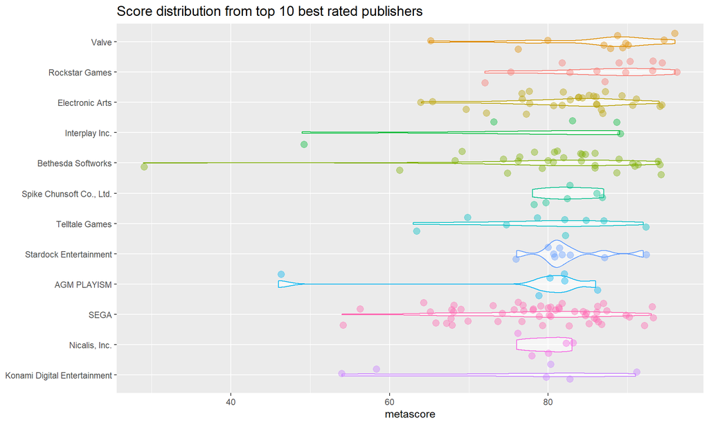

All of them have a meddian metascore above 80 points!

Now let’s take a look at the evolution of the metascores and the amount of titles released through the years

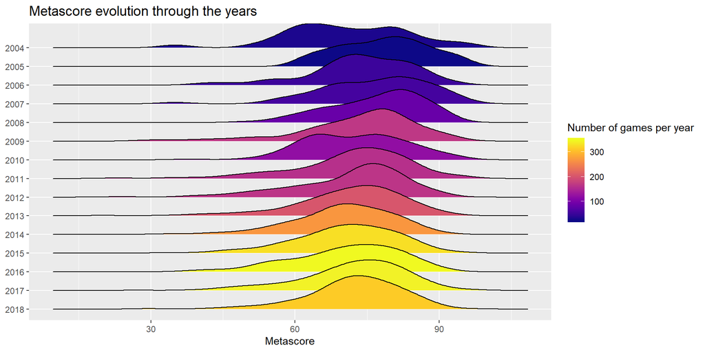

It seems that with the increasing amount of titles released each year the metascore distribution got more uniform through the years.

It would be interesting to catch a trend in prices too:

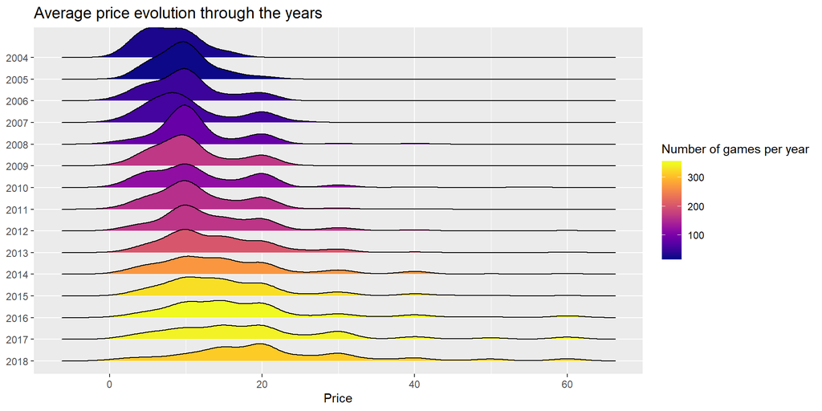

Effectively, prices seems to have suffered a rise lately.

Another way to look at it, allowing us to quantify *how much* the average price have risen:

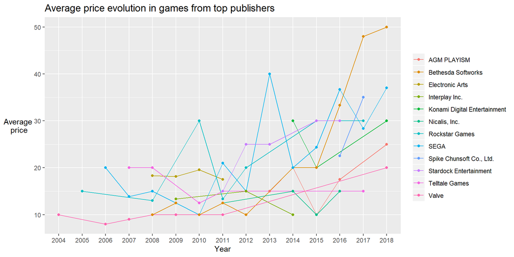

That rise in price could be justified by an increase in the quality of the products. So the question is: does the trend in metascores match the trend in prices?

Here we try to adress that question, including also the number of games per year, trying to detect if publishers are now trying to develop *less amount* but *better* video games.

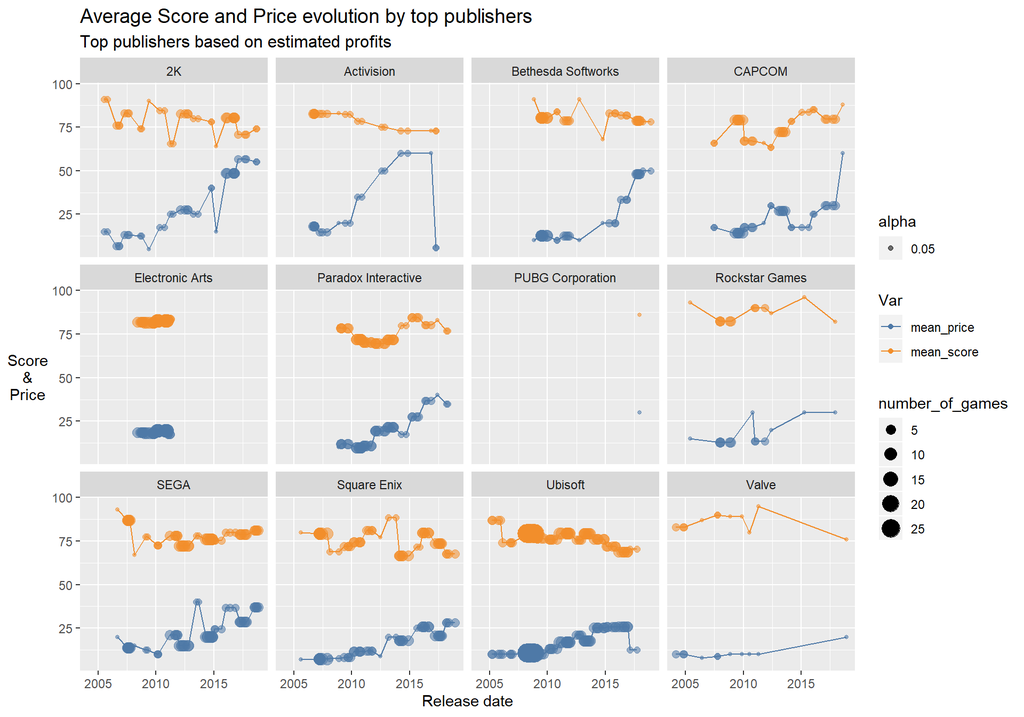

It seems that publishers are raising *prices* but *score* has the opposite trend, especially in companies like 2K.

To finish, let’s take a look to best sellers and their metascores:

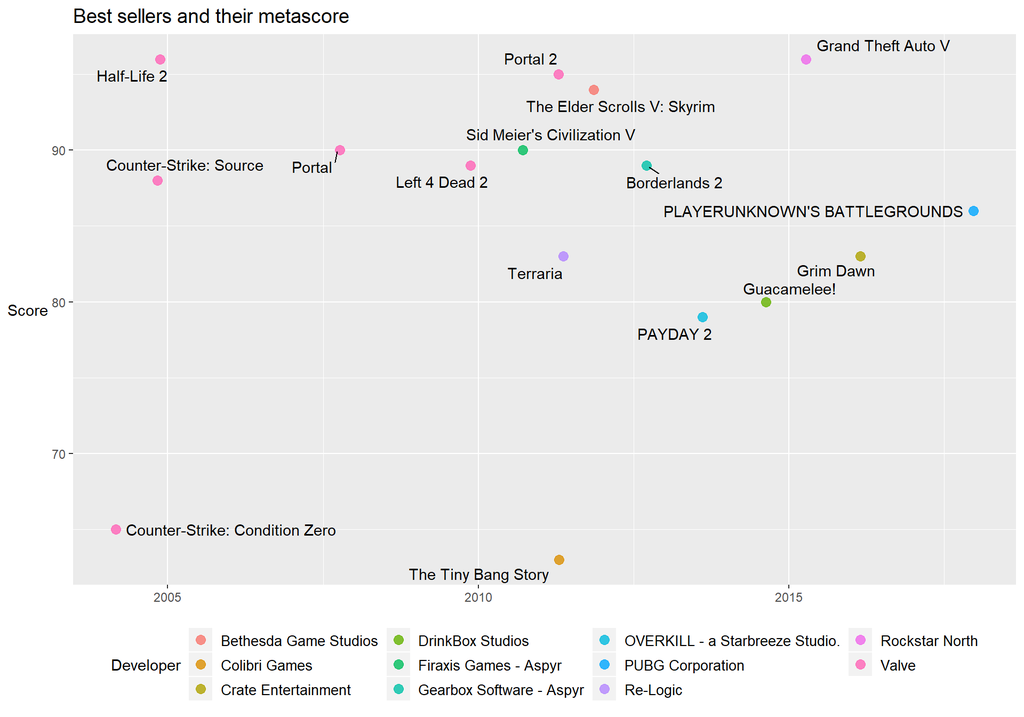